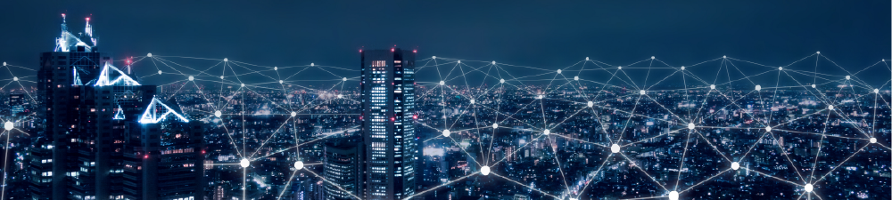

# Mini Project 2 - IU 4.5 Statistical Analysis

## Packages and setup

```python
import numpy as np
import pandas as pd
import seaborn as sns
import matplotlib.pyplot as plt
import os

from scipy.stats import shapiro
import scipy.stats as stats

#parameter settings
from IPython.core.interactiveshell import InteractiveShell
InteractiveShell.ast_node_interactivity = "all"
import warnings
warnings.filterwarnings("ignore")
warnings.simplefilter(action='ignore', category=FutureWarning)
```

### Reading data and initial processing

```python
#Read data using pandas
user_df=pd.read_csv("Mini_project_2_Data.xls")

#Check data types of each column using "dtypes" function
print("Data types for the data set:")
user_df.dtypes

#Check dimension of data i.e. # of rows and #column using pandas "shape" funtion
print("Shape of the data i.e. no. of rows and columns")
user_df.shape

#display first 5 rows of the data using "head" function
print("First 5 rows of the raw data:")
user_df.head()
```

```
Data types for the data set:
```

```
userid             int64
version           object
sum_gamerounds     int64
retention_1         bool
retention_7         bool
dtype: object
```

```
Shape of the data i.e. no. of rows and columns
```

```
(90189, 5)
```

```
First 5 rows of the raw data:
```

|  | userid | version | sum_gamerounds | retention_1 | retention_7 |
| --- | --- | --- | --- | --- | --- |
| 0 | 116 | gate_30 | 3 | False | False |
| 1 | 337 | gate_30 | 38 | True | False |
| 2 | 377 | gate_40 | 165 | True | False |
| 3 | 483 | gate_40 | 1 | False | False |
| 4 | 488 | gate_40 | 179 | True | True |

## Q1. Detect and resolve problems in the data (Missing value, Outliers, etc.)

### Q1.1 Identify missing value

```python
#Checking if there is NULL
user_df.isnull().sum()
```

```
userid            0
version           0
sum_gamerounds    0
retention_1       0
retention_7       0
dtype: int64
```

**Conclusion:** There is no missing value in this dataset.

### Q1.2 Identify outliers

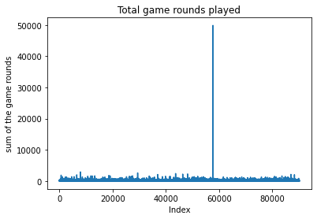

```python
#Check for outlier values in sum_gamerounds column
plt.title("Total game rounds played")
plt.xlabel("Index")
plt.ylabel("sum of the game rounds")
plt.plot(user_df.sum_gamerounds)
```

```python
#Based on the plot, filter out the outlier from sum_gamerounds played; Use max() function to find the index of the outlier

## Maximum Value of sum_gamerounds
max_sum=user_df.sum_gamerounds.max()

print('The outlier from sum_gameround is', max_sum)
```

```
The outlier from sum_gameround is 49854
```

```python
## Finding the index
indexname=(user_df[user_df['sum_gamerounds']==49854].index.values)

print('The index name is',indexname)
```

```
The index name is [57702]
```

```python
#Update the data by removing the identified outlier

update_user_df = user_df.drop(index = indexname)
update_user_df.shape
```

```
(90188, 5)
```

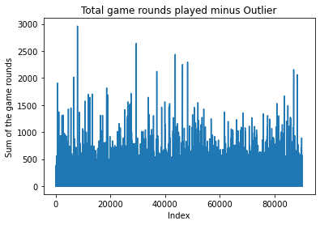

```python
#Plot the graph for sum_gamerounds player after removing the outlier

plt.title("Total game rounds played minus Outlier")
plt.xlabel("Index")
plt.ylabel("Sum of the game rounds")
plt.plot(update_user_df.sum_gamerounds)
```

The updated graph **without Outlier.**

## Q2. Plot summary statistics and identify trends to answer basis business questions

### Q2.1 What is the overall 7-day retention rate of the game?

```python
#Insert calculation for 7-day retention rate

df7 = update_user_df.retention_7[user_df.retention_7==True].count()
dftotal = update_user_df.retention_7.count()

retention_rate_7=df7/dftotal*100
formatted_7 = "{:.2f}".format(retention_rate_7)

print("Overall 7 days retention rate of the game for both versions is:",formatted_7,"%")
```

```
Overall 7 days retention rate of the game for both versions is: 18.61 %
```

**Conclusion**: Overall 7 days retention rate of the game for both versions is: **18.61%**

### Q2.2 How many players never played the game after installing?

```python
# Find number of customers with sum_gamerounds is equal to zero

dnp = update_user_df.sum_gamerounds[update_user_df.sum_gamerounds==0].count()
print('Number of players who never played the game after installing it is',dnp)
```

```
Number of players who never played the game after installing it is 3994
```

**Conclusion**: **3994 players** never played the game after installing it.

### Q2.3 Does the number of users decrease as the level progresses highlighting the difficulty of the game?

```python
# Group by sum_gamerounds and count the number of users for the first 200 gamerounds
df2 = update_user_df[(update_user_df["sum_gamerounds"] > 0) & (update_user_df["sum_gamerounds"] <= 200)]
theplot = df2.groupby("sum_gamerounds")["userid"].count()

theplot.head()
```

```
sum_gamerounds
1    5538
2    4606
3    3958
4    3629
5    2992
Name: userid, dtype: int64
```

```
<function matplotlib.pyplot.show(*args, **kw)>
```

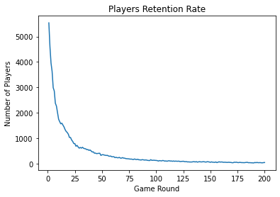

```python
#Use plot() function on the sumarized stats to visualize the chart
plt.title("Players Retention Rate")
plt.xlabel("Game Round")
plt.ylabel("Number of Players")
plt.plot(theplot)

plt.show
```

**Conclusion**: The players **decreased** as the game round progressed.

## Q3. Generate crosstab for two groups of players to understand if there is a difference in 7 days retention rate & total number of game rounds played

### Q3.1 Seven days retention rate summary for different game versions

```python
#Cross tab for game version and retention_1 flag counting number of users for each possible categories

cs1=pd.crosstab(update_user_df.version, update_user_df.retention_1).apply(lambda r: r/r.sum(), axis=1)
display(cs1)
```

| retention_1 version | False | True |
| --- | --- | --- |
| gate_30 | 0.551802 | 0.448198 |
| gate_40 | 0.557717 | 0.442283 |

```python
#Cross tab for game version and retention_7 flag counting number of users for each possible categories

cs7=pd.crosstab(update_user_df.version, update_user_df.retention_7).apply(lambda r: r/r.sum(), axis=1)
display(cs7)
```

| retention_7 version | False | True |
| --- | --- | --- |
| gate_30 | 0.809817 | 0.190183 |
| gate_40 | 0.818000 | 0.182000 |

```python
# Difference of gate_30 and gate_40 for retention_1 and retention_7

difference_1=round((cs1.loc["gate_30", True]-cs1.loc["gate_40", True])*100, 2)
difference_7=round((cs7.loc["gate_30", True]-cs7.loc["gate_40", True])*100, 2)

print("The difference between two player groups in one day is",difference_1,"%")
print("The difference between two player groups after seven days is",difference_7,"%")
```

```
The difference between two player groups in one day is 0.59 %
The difference between two player groups after seven days is 0.82 %
```

**Analysis Results:**

**Conclusion**: There is **very little difference** (less than 1%) between the two player groups, with group A (gate_30) having a slight advantage.

### Q3.2 Gamerounds summary for different game versions

```python
#use pandas group by to calculate average game rounds played summarized by different versions

update_user_df.groupby('version')['sum_gamerounds'].mean()
```

```
version
gate_30    51.342111
gate_40    51.298776
Name: sum_gamerounds, dtype: float64
```

**Analysis Results:**

Do total number of gamerounds played in total by each player differ based on different versions of the game?

**Conclusion**: Players on each group play pretty much **the same number** of game rounds.

## Q4. Perform two-sample test for groups A and B to test statistical significance amongst the groups in the sum of game rounds played i.e., if groups A and B are statistically different

### Initial data processing

```python
# Define A/B groups for hypothesis testing
update_user_df["version"] = np.where(update_user_df["version"] == "gate_30", "A", "B")
update_user_df.head()
```

|  | userid | version | sum_gamerounds | retention_1 | retention_7 |
| --- | --- | --- | --- | --- | --- |
| 0 | 116 | A | 3 | False | False |
| 1 | 337 | A | 38 | True | False |
| 2 | 377 | B | 165 | True | False |
| 3 | 483 | B | 1 | False | False |
| 4 | 488 | B | 179 | True | True |

```python
# Splitting the group using the sum_gamerounds

##Group A (Level 30)
group_A=pd.DataFrame(update_user_df[update_user_df.version=="A"]['sum_gamerounds'])
```

```python
group_A.head()
```

|  | sum_gamerounds |
| --- | --- |
| 0 | 3 |
| 1 | 38 |
| 6 | 0 |
| 11 | 0 |
| 13 | 39 |

```python
##Group B (Level 40)
group_B=pd.DataFrame(update_user_df[update_user_df.version=="B"]['sum_gamerounds'])
```

```python
group_B.head()
```

|  | sum_gamerounds |
| --- | --- |
| 2 | 165 |
| 3 | 1 |
| 4 | 179 |
| 5 | 187 |
| 7 | 2 |

### Q4.1 Shapiro test of Normality

```python
#---------------------- Shapiro Test ----------------------
# NULL Hypothesis H0: Distribution is normal
# ALTERNATE Hypothesis H1: Distribution is not normal

# Shapiro-Wilk Normality Test
## Shapiro-Wilk tests whether a data sample has a Gaussian distribution

from scipy.stats import shapiro

#test for group_A
print(shapiro(group_A))

print()
#test for group_B
print(shapiro(group_B))
```

```
ShapiroResult(statistic=0.48864424228668213, pvalue=0.0)

ShapiroResult(statistic=0.4825654625892639, pvalue=0.0)
```

**Analysis Results:**

Analyze and interpret the results of shapiro test of normality i.e. are the two groups normally distributed?

**Conclusion**: The Shapiro-Wilk test examines if a variable is normally distributed in a population. Based on the testing, the two groups are **not** normally distributed because the p-value is **less than the threshold value of 0.05.**

### Q4.2 Test of homegienity of variance

```python
#---------------------- Leven's Test ----------------------
# NULL Hypothesis H0: Two groups have equal variances
# ALTERNATE Hypothesis H1: Two groups do not have equal variances

from scipy.stats import levene

#perform levene's test and accept or reject the null hypothesis based on the results
levene(group_A["sum_gamerounds"], group_B["sum_gamerounds"])
```

```
LeveneResult(statistic=0.07510153837481241, pvalue=0.7840494387892463)
```

**Analysis Results:**

**Conclusion**: Levene’s Test is used to determine whether two or more groups have equal variances. Based on the testing,the p-value of the test is **NOT less than the threshold value of 0.05** and we **fail to reject the null hypothesis that the sample groups have equal variance**.

### Q4.3 Test of significance: Two sample test

```python
#---------------------- Two samples test ----------------------
# NULL Hypothesis H0: Two samples are equal
# ALTERNATE Hypothesis H1: Two samples are different

from scipy.stats import mannwhitneyu

#Apply relevant two sample test to accept or reject the NULL hypothesis
mannwhitneyu(group_A, group_B)
```

```
MannwhitneyuResult(statistic=1009027049.5, pvalue=0.02544577639572688)
```

**Analysis Results:**

**Conclusion**: The Mann-Whitney U test is used to compare differences between two independent groups when the dependent variable is either ordinal or continuous, but not normally distributed. Based on the test above, the statistic is **1009027049.5** and the corresponding p-value is **0.02544577639572688**. Since the p-value is less than 0.05, **the null hypothesis can be rejected. (ie.e. the 2 samples are statistically different, and Group A's sum of gamerounds are statistically different from that of Group B)**

## Q5. Based on significance testing results, if groups A and B are statistically different, which level has more advantage in terms of player retention and number of game rounds played

```python
#Analyze the 1 day and 7 days retention rate for two different groups using group by function
update_user_df.groupby(('version'))[['retention_1','retention_7','sum_gamerounds']].mean()
```

| version | retention_1 | retention_7 | sum_gamerounds |
| --- | --- | --- | --- |
| A | 0.448198 | 0.190183 | 51.342111 |
| B | 0.442283 | 0.182000 | 51.298776 |

**Analysis Results:**

**Conclusion**: **Group A (Level 30) has a slight advantage in terms of player retention, and the number of game rounds played between the two groups are more or less the same.**

## Q6. [Bonus Question] Using bootstrap resampling, plot the retention rate distribution for both the groups in order to visualize effect of different version of the game on retention.

```python
# Creating empty lists
bootstrap_1=[]
bootstrap_7=[]

# Plucking numbers for retention_1 to fill the list
for i in range(1001):
        mean_diff = update_user_df.sample(frac=.3,replace=True).groupby("version")["retention_1"].mean()
        bootstrap_1.append(mean_diff)

# Plucking numbers for retention_7 to fill the list
for i in range(1001):
        mean_diff = update_user_df.sample(frac=.3,replace=True).groupby("version")["retention_7"].mean()
        bootstrap_7.append(mean_diff)

print(f"bootstrap_1: {bootstrap_1[:5]}")
print()
print(f"bootstrap_7: {bootstrap_7[:5]}")
```

```
bootstrap_1: [version
A    0.449775
B    0.437719
Name: retention_1, dtype: float64, version
A    0.451292
B    0.439579
Name: retention_1, dtype: float64, version
A    0.448394
B    0.438806
Name: retention_1, dtype: float64, version
A    0.453600
B    0.442245
Name: retention_1, dtype: float64, version
A    0.445521
B    0.446546
Name: retention_1, dtype: float64]

bootstrap_7: [version
A    0.193459
B    0.179829
Name: retention_7, dtype: float64, version
A    0.191786
B    0.186657
Name: retention_7, dtype: float64, version
A    0.188898
B    0.182808
Name: retention_7, dtype: float64, version
A    0.192676
B    0.180902
Name: retention_7, dtype: float64, version
A    0.191820
B    0.181577
Name: retention_7, dtype: float64]
```

```python
# Converting the list to a dataframe

# Bootstrap 1
df_b1 = pd.DataFrame(bootstrap_1)
display(df_b1.head())

# Bootstrap 7
df_b7 = pd.DataFrame(bootstrap_7)
display(df_b7.head())
```

| version | A | B |
| --- | --- | --- |
| retention_1 | 0.449775 | 0.437719 |
| retention_1 | 0.451292 | 0.439579 |
| retention_1 | 0.448394 | 0.438806 |
| retention_1 | 0.453600 | 0.442245 |
| retention_1 | 0.445521 | 0.446546 |

| version | A | B |
| --- | --- | --- |
| retention_7 | 0.193459 | 0.179829 |
| retention_7 | 0.191786 | 0.186657 |
| retention_7 | 0.188898 | 0.182808 |
| retention_7 | 0.192676 | 0.180902 |
| retention_7 | 0.191820 | 0.181577 |

```
One Day Retention Rate
```

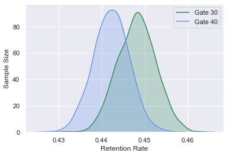

```python
# Plotting density chart (One Day Retention Rate)

# set a grey background
sns.set(style="darkgrid")

# plotting both distibutions on the same figure
fig = sns.kdeplot(df_b1['A'], shade=True, color="seagreen")
fig = sns.kdeplot(df_b1['B'], shade=True, color="cornflowerblue")

plt.xlabel('Retention Rate')
plt.ylabel('Sample Size')

plt.legend(labels=["Gate 30","Gate 40"])

print('\033[1mOne Day Retention Rate')

plt.show()
```

```
Seven Days Retention Rate
```

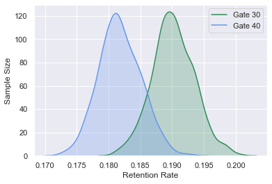

```python
# Plotting density chart (Seven Days Retention Rate)

# set a grey background
sns.set(style="darkgrid")

# plotting both distibutions on the same figure
fig = sns.kdeplot(df_b7['A'], shade=True, color="seagreen")
fig = sns.kdeplot(df_b7['B'], shade=True, color="cornflowerblue")

plt.xlabel('Retention Rate')
plt.ylabel('Sample Size')

plt.legend(labels=["Gate 30","Gate 40"])

print('\033[1mSeven Days Retention Rate')

plt.show()
```

**Conclusion**: Based on the two charts above, **the retention rate would decrease as the version goes up**, and **players gradually dropped as time goes by (one day versus seven days).**